# Séance 5 : Représenter les données

L’Amérique crée-t-elle plus de valeur que tout autre pays ? Cela dépend du graphique

Thierry Warin, PhD

HEC Montréal

## Plan · La séance

1. Une manchette, quatre réponses
2. Pourquoi un graphique : le quartet d’Anscombe
3. Ce que l’œil lit bien : Cleveland et McGill
4. PyStatlas : une galerie rangée par question
5. L’anatomie d’un script PyStatlas
6. La méthode : trouver, copier, remplacer, réécrire
7. Ce que la galerie ne fait pas pour vous
8. Du mauvais graphique au bon

## À quoi sert la séance 5

### La stratégie

- Montrer qu’une même affirmation (« l’Amérique crée plus de valeur ») change de réponse selon la **mesure**
- Choisir le graphique qu’un comité de direction lira **sans aide**
- Repérer un graphique qui trompe, même sans mentir

### Le Python

- Lire un script de la galerie **PyStatlas** et l’adapter à nos données
- Construire une figure avec `fig, ax = plt.subplots()` et l’enregistrer avec `savefig`
- Appliquer un style commun (`pystatlas.mplstyle`) ; explorer avec **plotly express**

### La méthode

- Partir de la **question**, puis choisir la famille de graphiques
- Titrer par le **message** ; mettre la **statistique** en sous-titre
- Unités, source, étiquetage direct

# Une manchette, quatre réponses

## « L’Amérique crée plus de valeur que tout autre pays »

```python
import pandas as pd
pays = pd.read_csv("data/pays.csv")
pays["region"] = pays["region"].str.strip()      # la Banque mondiale laisse des espaces
p23 = pays[pays["annee"] == 2023]

mesures = ["pib_milliards_usd", "pib_hab_usd", "croissance_pib", "ide_entrants_pct_pib"]
rangs = {m: p23[m].rank(ascending=False)[p23["iso3"] == "USA"].iloc[0] for m in mesures}
pd.DataFrame({"rang des États-Unis": rangs,
              "nombre de pays mesurés": p23[mesures].notna().sum()}).astype(int)
```

|  | rang des États-Unis | nombre de pays mesurés |
| --- | --- | --- |
| pib_milliards_usd | 1 | 204 |
| pib_hab_usd | 11 | 204 |
| croissance_pib | 113 | 204 |
| ide_entrants_pct_pib | 132 | 195 |

Premier en **taille**, onzième en **niveau de vie**, loin derrière en **croissance** et en **attractivité** pour l’investissement étranger. La manchette ne précise pas la mesure ; le graphique, lui, devra la choisir.

## La même question, quatre graphiques

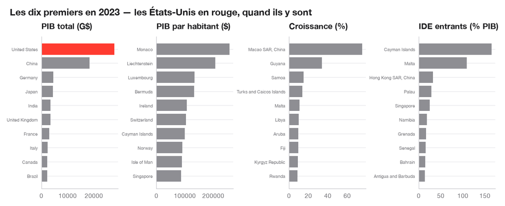

```python
import matplotlib.pyplot as plt
plt.style.use("05-representer-les-donnees/pystatlas.mplstyle")   # le style de la galerie
BLEU, ORANGE, VERT, ROUGE, GRIS = "#007AFF", "#FF9500", "#34C759", "#FF3B30", "#8E8E93"

fig, axes = plt.subplots(1, 4, figsize=(11, 4.4))
titres = ["PIB total (G$)", "PIB par habitant ($)", "Croissance (%)", "IDE entrants (% PIB)"]
for ax, m, t in zip(axes, mesures, titres):
    top = p23.nlargest(10, m).sort_values(m)
    ax.barh(top["pays"], top[m], color=[ROUGE if i == "USA" else GRIS for i in top["iso3"]])
    ax.set_title(t)
    ax.tick_params(axis="y", labelsize=7)
fig.suptitle("Les dix premiers en 2023 — les États-Unis en rouge, quand ils y sont", x=0.01, ha="left")
plt.show()
```

## Ce que la figure vient de faire

- Elle a **choisi** de ne garder que les dix premiers : les États-Unis disparaissent de trois panneaux sur quatre.
- Elle a **choisi** une couleur d’accent : l’œil va au rouge avant de lire les noms.
- Elle a **trié** les barres : sans tri, aucune comparaison n’est possible.

Un graphique n’est jamais neutre. Chaque choix — mesure, échantillon, ordre, couleur, échelle — est un argument. L’objet de la séance est de faire ces choix **délibérément** et de les annoncer.

# Pourquoi un graphique

## Le quartet d’Anscombe (1973)

Quatre jeux de onze points, publiés par Francis Anscombe pour une seule démonstration.

```python
x  = [10, 8, 13, 9, 11, 14, 6, 4, 12, 7, 5]
x4 = [8, 8, 8, 8, 8, 8, 8, 19, 8, 8, 8]
anscombe = pd.DataFrame({
    "I":   list(zip(x,  [8.04, 6.95, 7.58, 8.81, 8.33, 9.96, 7.24, 4.26, 10.84, 4.82, 5.68])),
    "II":  list(zip(x,  [9.14, 8.14, 8.74, 8.77, 9.26, 8.10, 6.13, 3.10, 9.13, 7.26, 4.74])),
    "III": list(zip(x,  [7.46, 6.77, 12.74, 7.11, 7.81, 8.84, 6.08, 5.39, 8.15, 6.42, 5.73])),
    "IV":  list(zip(x4, [6.58, 5.76, 7.71, 8.84, 8.47, 7.04, 5.25, 12.50, 5.56, 7.91, 6.89])),
}).melt(var_name="jeu", value_name="xy")
anscombe[["x", "y"]] = pd.DataFrame(anscombe["xy"].tolist(), index=anscombe.index)
anscombe = anscombe.drop(columns="xy")

stats_ = anscombe.groupby("jeu").agg(moy_x=("x", "mean"), moy_y=("y", "mean"), var_y=("y", "var"))
stats_["corr"] = anscombe.groupby("jeu")[["x", "y"]].corr().xs("x", level=1)["y"]
stats_.round(2)
```

| jeu | moy_x | moy_y | var_y | corr |
| --- | --- | --- | --- | --- |
| I | 9.0 | 7.5 | 4.13 | 0.82 |
| II | 9.0 | 7.5 | 4.13 | 0.82 |
| III | 9.0 | 7.5 | 4.12 | 0.82 |
| IV | 9.0 | 7.5 | 4.12 | 0.82 |

Mêmes moyennes, même variance, même corrélation. **Les tableaux disent que ce sont les mêmes données.**

## Les graphiques disent le contraire

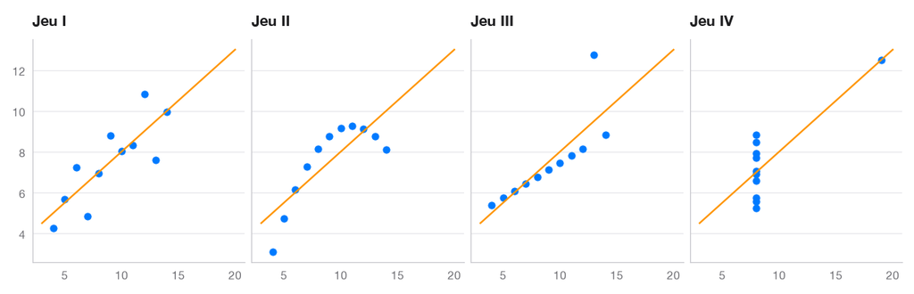

```python
import numpy as np
fig, axes = plt.subplots(1, 4, figsize=(11, 3.4), sharex=True, sharey=True)
for ax, (jeu, d) in zip(axes, anscombe.groupby("jeu")):
    ax.scatter(d["x"], d["y"], color=BLEU)
    b, a = np.polyfit(d["x"], d["y"], 1)
    xs = np.array([3, 20])
    ax.plot(xs, a + b * xs, color=ORANGE, lw=1.5)
    ax.set_title(f"Jeu {jeu}")
plt.show()
```

Une relation linéaire, une courbe, une valeur aberrante qui tord la droite, un seul point qui **fabrique** la corrélation. Regardez **avant** de résumer.

# Ce que l’œil lit bien

## La hiérarchie de Cleveland et McGill (1984)

Des expériences de perception ont classé les façons d’encoder un nombre, de la plus précise à la moins précise :

| Rang | Encodage | Exemple |
| --- | --- | --- |
| **1** | Position sur une échelle commune | Nuage de points, barres alignées |
| **2** | Position sur des échelles non alignées | Petits multiples |
| **3** | Longueur | Barres empilées |
| **4** | Angle, pente | Secteurs (« camembert ») |
| **5** | Aire | Bulles, cartes proportionnelles |
| **6** | Volume, saturation, teinte | Graphiques en 3D, cartes colorées |

Mettez la comparaison **la plus importante** sur l’encodage **le plus précis**. La couleur sert à grouper ou à attirer l’œil, rarement à faire lire une quantité.

## Angle contre position : les mêmes six nombres

Allemagne ou Japon : lequel est le plus gros ? À gauche, on devine ; à droite, on lit.

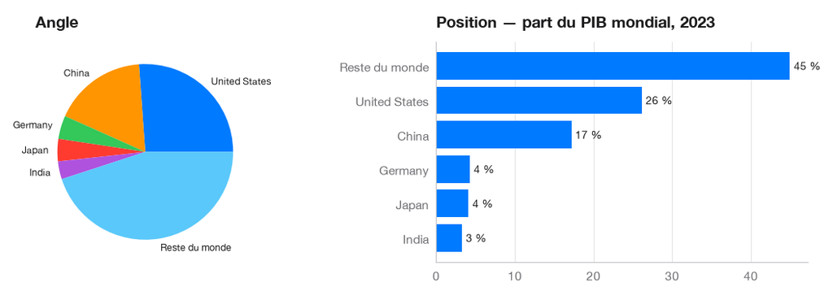

```python
top5 = p23.nlargest(5, "pib_milliards_usd").set_index("pays")["pib_milliards_usd"]
autres = p23["pib_milliards_usd"].sum() - top5.sum()
parts = pd.concat([top5, pd.Series({"Reste du monde": autres})]) / p23["pib_milliards_usd"].sum()

fig, (a1, a2) = plt.subplots(1, 2, figsize=(10, 3.2))
a1.pie(parts, labels=parts.index, textprops={"fontsize": 8})
a1.set_title("Angle")
s = parts.sort_values()
a2.barh(s.index, s * 100, color=BLEU)
for i, v in enumerate(s * 100):
    a2.text(v + 0.5, i, f"{v:.0f} %", va="center", fontsize=9)
a2.set_title("Position — part du PIB mondial, 2023")
a2.grid(axis="x"); a2.grid(axis="y", visible=False)
plt.show()
```

# PyStatlas : une galerie rangée par question

## Ce qu’est PyStatlas

**[warint.github.io/pystatlas/fr](https://warint.github.io/pystatlas/fr/)** · code : github.com/warint/pystatlas

- **Une soixantaine de graphiques statistiques**, rangés par **famille de questions**, chacun avec son script Python complet
- Pensée d’abord pour les **étudiants en sciences sociales** : on part de la question, pas du code
- Des exemples sur de **vraies données de sciences sociales** : élections américaines, écoles californiennes, criminalité, fécondité, régimes politiques, récidive — références complètes : [Sources des données](https://warint.github.io/pystatlas/fr/about.html#data)
- Construite sur ce que vous avez déjà : NumPy, pandas, Matplotlib, SciPy, statsmodels

Trois principes, qui sont aussi ceux du cours :

| Principe | Ce que cela veut dire pour vous |
| --- | --- |
| **Autonome** | Chaque script s’exécute tel quel ; aucun fichier caché, aucune fonction maison |
| **La statistique d’abord** | Le graphique affiche les chiffres qui comptent : n, médiane, test, taille d’effet |
| **Un dossier = une page** | `gallery/<famille>/<graphique>/plot.py` : on lit, on copie, on adapte |

## Les familles, et les questions du stratège

| La question | La famille PyStatlas | Graphiques utiles aujourd’hui | Séance |
| --- | --- | --- | --- |
| Quelle **forme** a cette variable ? | Distributions | Histogramme avec densité, crêtes, fonctions de répartition | **05** |
| Ces **groupes** diffèrent-ils ? | Comparaisons de groupes ; Distributions | Nuage de pluie, comparaison entre groupes | **05**, 06 |
| Ces deux variables **vont-elles ensemble** ? | Corrélation et association | Nuage de points avec statistiques, matrice de corrélation | **05**, 06 |
| Quelle **part** de chaque groupe ? | Proportions et enquêtes | Proportions empilées, proportions avec IC | 07–10 |
| Qu’est-ce qui **explique** le résultat ? | Modèles de régression ; Diagnostics | Graphique de coefficients, résidus | 06, cas |
| — | Séries chronologiques, Survie, Multivarié, Inférence |  | cas, projets |

On n’apprend pas soixante graphiques. On apprend à **partir de la question**, à trouver la famille, et à lire un script assez bien pour le faire travailler sur ses propres données.

# L’anatomie d’un script PyStatlas

## Quatre blocs, toujours dans le même ordre

Extrait de *Histogramme avec densité* ([distributions/histogram-density](https://warint.github.io/pystatlas/fr/distributions/histogram-density/)) :

```python
"""
title: Histogram with density            ← 1. LA FICHE : ce que montre le graphique,
summary: Histogram, kernel density ...      son équivalent R, ses mots-clés
"""
import statsmodels.api as sm
from scipy import stats

wb = sm.datasets.fertility.load_pandas().data                         # ← 2. LES DONNÉES
x = wb["2011"].dropna().to_numpy()            # fécondité de chaque pays en 2011
mean, median, sd = x.mean(), np.median(x), x.std(ddof=1)

skew, kurt = stats.skew(x), stats.kurtosis(x)                          # ← 3. LA STATISTIQUE
W, p = stats.shapiro(x)

fig, ax = plt.subplots(figsize=(8, 5))                                 # ← 4. LA FIGURE
ax.hist(x, bins=30, density=True, ...)
ax.set_title(f"Fertility is right-skewed: median {median:.1f} births per woman, "
             f"{(x > 5).sum()} countries above 5", pad=26)            #    titre = le message
ax.text(0, 1.02, f"n = {len(x)} · skewness = {skew:.2f} · ...",        #    sous-titre = la preuve
        transform=ax.transAxes, fontsize=9.5, color="#6E6E73")
```

Pour adapter un script, vous ne touchez **que** le bloc 2 (vos données), puis les **textes** du bloc 4 (titre, axes, sous-titre). Les blocs 3 et 4 font le reste.

## `fig` et `ax` : la toile et le cadre

Tous les scripts de la galerie suivent la même grammaire matplotlib :

```python
fig, ax = plt.subplots(figsize=(8, 5))   # fig : la page ; ax : un système d'axes
ax.hist(x)                               # ce qu'on dessine va dans ax
ax.set_title("Le message, pas le sujet")
ax.set_xlabel("PIB par habitant ($ US courants)")
ax.text(0, 1.02, "n = 204 · médiane = …", transform=ax.transAxes)   # sous-titre statistique
fig.text(0.01, -0.02, "Source : Banque mondiale, WDI", fontsize=8)  # source
fig.savefig("sorties/figure.png")        # 200 dpi et marges ajustées : le style s'en charge
```

| Élément | Règle |
| --- | --- |
| **Titre** | Il dit la conclusion : « Le Canada décroche des États-Unis depuis 2014 » |
| **Sous-titre** | Le n, la statistique, le test : ce qui permet de **vérifier** le titre |
| **Axes** | Une étiquette **avec l’unité** |
| **Source** | Toujours, en bas, en petit |

## Le style : une ligne pour toutes vos figures

```python
plt.style.use("05-representer-les-donnees/pystatlas.mplstyle")
```

Le fichier [`pystatlas.mplstyle`](https://github.com/warint/pystatlas/blob/main/pystatlas.mplstyle) est copié dans le dossier de la séance. Il règle une fois pour toutes :

| Réglage | Effet |
| --- | --- |
| `axes.spines.top/right : False` | Pas de cadre inutile |
| `axes.grid.axis : y`, gris très pâle | Une grille qui aide sans se voir |
| `axes.titlelocation : left` | Le titre se lit comme une manchette |
| `axes.prop_cycle` | Une palette de dix couleurs nettes, la même partout |
| `savefig.dpi : 200`, `savefig.bbox : tight` | Un PNG prêt pour un rapport |

`plt.show()` **vide** la figure dans un script. Appelez `savefig` **avant** `show`, sinon vous enregistrez une page blanche.

# La méthode : trouver, copier, remplacer, réécrire

## Les quatre gestes

|  | Geste | Ce que vous faites |
| --- | --- | --- |
| **1** | **Trouver** | Formulez la question, ouvrez la famille, choisissez le graphique |
| **2** | **Copier** | Bouton « Copier le code » ; collez dans une cellule `# %%` |
| **3** | **Remplacer** | Le bloc « données » : `pd.read_csv("data/…")` à la place du jeu d’exemple |
| **4** | **Réécrire** | Titre-message, unités, sous-titre en français, source |

Cinq démonstrations sur **nos** données, une par question.

Les exemples de la galerie sont déjà des données de sciences sociales, fournies avec **statsmodels** ou **lifelines**. Lisez-les pour comprendre le graphique, puis remplacez ces lignes par nos données : c’est le geste 3.

## 1 · Distribution : histogramme avec densité

[distributions/histogram-density](https://warint.github.io/pystatlas/fr/distributions/histogram-density/) · *quelle forme a le PIB par habitant ?*  
*Exemple de la galerie : fécondité de 198 pays en 2011 : médiane de 2,3 enfants par femme, longue traîne à droite.*

```python
from scipy import stats

# 2. DONNÉES — la seule ligne vraiment changée
x = p23["pib_hab_usd"].dropna().to_numpy() / 1000
mean, median, sd = x.mean(), np.median(x), x.std(ddof=1)
skew, kurt = stats.skew(x), stats.kurtosis(x)

# 4. FIGURE — reprise de la galerie, textes réécrits
fig, ax = plt.subplots(figsize=(10, 5))
ax.hist(x, bins=40, density=True, color=BLEU, alpha=0.25, edgecolor="white")
grid = np.linspace(0, x.max() * 1.05, 400)
ax.plot(grid, stats.gaussian_kde(x)(grid), color=BLEU, lw=2.2, label="Densité (noyau)")
ax.plot(grid, stats.norm.pdf(grid, mean, sd), color=GRIS, lw=1.6, ls="--", label="Loi normale, même moyenne et écart type")
ymax = ax.get_ylim()[1]
for v, nom, c, ha, dx in [(mean, "Moyenne", ORANGE, "left", 6), (median, "Médiane", VERT, "right", -6)]:
    ax.axvline(v, color=c, lw=1.6, ymax=0.9)
    ax.annotate(f"{nom}\n{v:,.1f} k$", (v, ymax * 0.9), xytext=(dx, -2), textcoords="offset points",
                ha=ha, va="top", fontsize=10, fontweight="semibold", color=c)
ax.set_xlim(0, grid[-1]); ax.set_yticks([])
ax.set(xlabel="PIB par habitant, 2023 (milliers de $ US courants)", ylabel="Densité")
ax.legend(loc="upper right")
ax.set_title("Quelques pays très riches tirent la moyenne loin au-dessus de la médiane", pad=26)
ax.text(0, 1.02, f"n = {len(x)} économies · asymétrie = {skew:.2f} · aplatissement = {kurt:.2f}",
        transform=ax.transAxes, fontsize=10, color="#6E6E73")
fig.text(0.01, -0.03, "Source : Banque mondiale, WDI · graphique adapté de PyStatlas", fontsize=8, color=GRIS)
plt.show()
```

## 1 · Distribution : histogramme avec densité

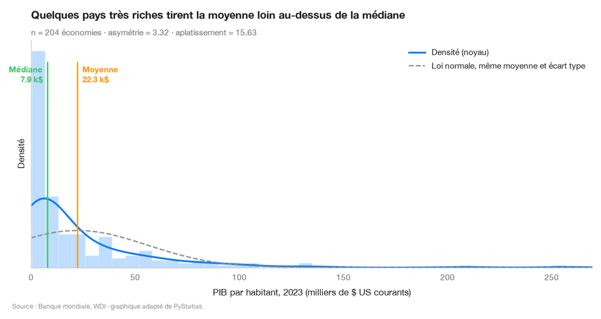

## Ce que la statistique ajoute au dessin

- La courbe grise est ce que l’on **supposerait** si le PIB par habitant était « normal » ; la bleue est ce que l’on **observe**. L’écart est le message.
- L’**asymétrie** (*skewness*) supérieure à 3 le chiffre : une longue traîne à droite.
- Conséquence pour la stratégie : la **moyenne** décrit un pays qui n’existe pas. Rapportez la **médiane**, et passez à l’**échelle logarithmique** pour comparer (c’est la figure 2 de la pratique).

Le sous-titre transforme une impression (« ça penche à droite ») en un fait vérifiable. C’est la passerelle vers la séance 6.

## 2 · Groupes : le nuage de pluie

[distributions/raincloud](https://warint.github.io/pystatlas/fr/distributions/raincloud/) · *la marge nette diffère-t-elle selon le secteur ?*  
*Exemple de la galerie : durée au pouvoir des dirigeants selon le type de régime (démocraties parlementaires, présidentielles, dictatures militaires).*

```python
ent = pd.read_csv("data/entreprises.csv")
ent["marge"] = ent["resultat_net"] / ent["chiffre_affaires"] * 100
choix = ["Commerce de détail", "Automobile", "Industrie", "Pharmaceutique", "Technologie"]
data = [ent.loc[ent["secteur"] == g, "marge"].dropna().to_numpy() for g in choix]
palette = [GRIS, ROUGE, ORANGE, VERT, BLEU]

H, p = stats.kruskal(*data)                     # test de Kruskal-Wallis + epsilon²
eps2 = H / (sum(len(d) for d in data) - 1)

fig, ax = plt.subplots(figsize=(10, 5.2))
rng = np.random.default_rng(7)
for i, (d, c) in enumerate(zip(data, palette)):
    grid = np.linspace(max(d.min(), -40), d.max() + 2, 300)
    dens = stats.gaussian_kde(d)(grid)
    ax.fill_between(grid, i, i + 0.55 * dens / dens.max(), color=c, alpha=0.3, lw=0)   # le nuage
    ax.plot(grid, i + 0.55 * dens / dens.max(), color=c, lw=1.4)
    ax.boxplot(d, positions=[i - 0.1], widths=0.09, vert=False, showfliers=False,       # la boîte
               patch_artist=True, boxprops=dict(facecolor="white", edgecolor="#3A3A3C", lw=1),
               medianprops=dict(color=c, lw=2.2), whiskerprops=dict(color="#3A3A3C"),
               capprops=dict(visible=False))
    ax.scatter(d, i - 0.3 + rng.uniform(-0.08, 0.08, len(d)), s=12, color=c, alpha=0.55, lw=0)  # la pluie
ax.set_yticks(range(len(choix)), [f"{g}\nmédiane {np.median(d):.1f} % · n = {len(d)}" for g, d in zip(choix, data)])
ax.set_ylim(-0.5, len(choix) - 0.3); ax.set_xlim(-40, 60)
ax.axvline(0, color=GRIS, lw=0.8)
ax.grid(axis="x"); ax.grid(axis="y", visible=False)
ax.set_xlabel("Marge nette (résultat net / chiffre d'affaires, %)")
med = dict(zip(choix, map(np.median, data)))
ax.set_title(f"La technologie garde {med['Technologie']:.0f} cents par dollar de ventes ; "
             f"le commerce de détail, {med['Commerce de détail']:.1f}".replace(".", ","), pad=26)
ax.text(0, 1.02, f"Kruskal-Wallis H(4) = {H:.0f}, p = {p:.0e}, ε² = {eps2:.2f} · une observation = une entreprise-année, 2010-2024",
        transform=ax.transAxes, fontsize=10, color="#6E6E73")
fig.text(0.01, -0.03, "Source : SEC EDGAR · axe coupé à −40 % (Tesla 2010-2012 hors champ) · adapté de PyStatlas", fontsize=8, color=GRIS)
plt.show()
```

## 2 · Groupes : le nuage de pluie

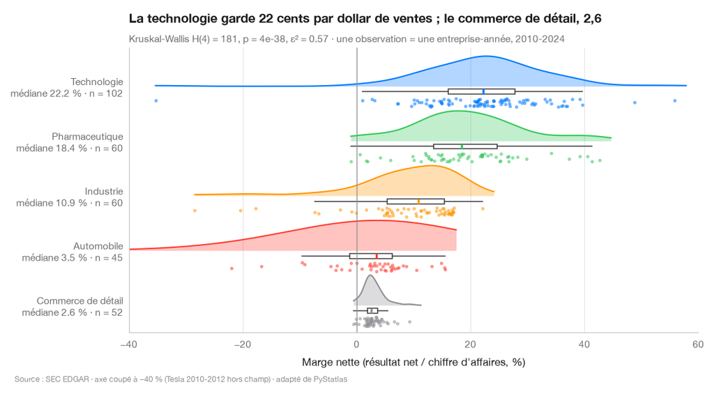

## Lire un nuage de pluie

| Couche | Ce qu’elle montre | Ce qu’elle remplace |
| --- | --- | --- |
| Le **nuage** (demi-violon) | La forme de la distribution | L’histogramme |
| La **boîte** | Médiane et quartiles | La boîte à moustaches |
| La **pluie** | Chaque entreprise-année | Le tableau de données |

Le test traite chaque **entreprise-année** comme indépendante. Or Apple 2015 et Apple 2016 ne sont pas deux tirages indépendants : la valeur p est trop optimiste. Le graphique reste juste ; la séance 6 corrige l’inférence.

L’axe est coupé à −40 % et la légende le **dit**. Couper sans le dire, c’est tromper.

## 3 · Relation : nuage de points avec statistiques

[correlation/scatter-with-stats](https://warint.github.io/pystatlas/fr/correlation/scatter-with-stats/) · *les pays riches commercent-ils plus ?*  
*Exemple de la galerie : 303 districts scolaires californiens : plus d’élèves défavorisés, moins d’élèves au-dessus de la médiane nationale en maths (r = −0,83).*

```python
import statsmodels.api as sm

d = p23.dropna(subset=["pib_hab_usd", "commerce_pct_pib"])
x, y = np.log10(d["pib_hab_usd"].to_numpy()), d["commerce_pct_pib"].to_numpy()
n = len(x)
res = stats.pearsonr(x, y); ci = res.confidence_interval(0.95)
fit = sm.OLS(y, sm.add_constant(x)).fit()
grid = np.linspace(x.min(), x.max(), 200)
band = fit.get_prediction(sm.add_constant(grid)).conf_int(alpha=0.05)

fig = plt.figure(figsize=(10, 5.4))
gs = fig.add_gridspec(2, 2, width_ratios=(5, 1), height_ratios=(1, 5), wspace=0.03, hspace=0.03)
ax = fig.add_subplot(gs[1, 0]); ax_top = fig.add_subplot(gs[0, 0], sharex=ax); ax_right = fig.add_subplot(gs[1, 1], sharey=ax)
ax.scatter(x, y, s=22, color=BLEU, alpha=0.45, lw=0)
ax.fill_between(grid, band[:, 0], band[:, 1], color=ORANGE, alpha=0.25, lw=0)
ax.plot(grid, fit.params[0] + fit.params[1] * grid, color=ORANGE, lw=2.2)
us = d["iso3"].to_numpy() == "USA"
ax.annotate("États-Unis", (x[us][0], y[us][0]), xytext=(8, -14), textcoords="offset points", color=ROUGE, fontweight="semibold")
ax.set_xticks([3, 4, 5], ["1 000 $", "10 000 $", "100 000 $"])
ax.set(xlabel="PIB par habitant, 2023 (échelle log)", ylabel="Commerce (exportations + importations, % du PIB)")
ax.grid(axis="x")
ax_top.hist(x, bins=30, color=BLEU, alpha=0.35, edgecolor="white")
ax_right.hist(y, bins=30, color=BLEU, alpha=0.35, edgecolor="white", orientation="horizontal")
for a in (ax_top, ax_right): a.axis("off")
ax_top.set_title("Les pays riches sont plus ouverts — les États-Unis font exception", pad=26)
ax_top.text(0, 1.06, f"Pearson r = {res.statistic:.2f}, IC 95 % [{ci.low:.2f}, {ci.high:.2f}], p < 0,001 · n = {n} économies",
            transform=ax_top.transAxes, fontsize=10, color="#6E6E73")
plt.show()
```

## 3 · Relation : nuage de points avec statistiques

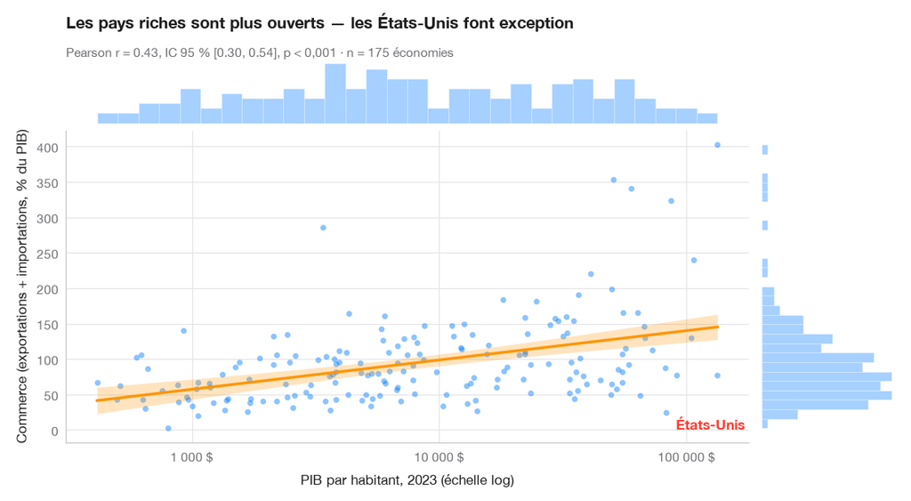

## 4 · Deux groupes : fonctions de répartition empiriques

[distributions/ecdf-comparison](https://warint.github.io/pystatlas/fr/distributions/ecdf-comparison/) · *les pays riches croissent-ils moins vite ?*  
*Exemple de la galerie : âge à la sortie de prison des hommes récidivistes et non récidivistes (étude de Rossi).*

```python
croiss = (pays[pays["annee"].between(2014, 2023)].groupby(["iso3", "revenu"])["croissance_pib"]
          .mean().reset_index().dropna())
groupes = {"Revenu élevé": croiss.loc[croiss["revenu"] == "High income", "croissance_pib"].to_numpy(),
           "Autres pays": croiss.loc[croiss["revenu"] != "High income", "croissance_pib"].to_numpy()}

ks = stats.ks_2samp(*groupes.values())          # D = le plus grand écart vertical
x_gap = ks.statistic_location
F = [stats.ecdf(g).cdf for g in groupes.values()]
y_gap = [f.evaluate(x_gap) for f in F]

lo, hi = -4, 9
fig, ax = plt.subplots(figsize=(10, 5))
for (nom, g), f, c in zip(groupes.items(), F, [BLEU, ORANGE]):
    ax.step(np.r_[lo, f.quantiles, hi], np.r_[0, f.probabilities, 1], where="post", color=c, lw=2,
            label=f"{nom} (n = {len(g)}, médiane {np.median(g):.1f} %)")
ax.plot([x_gap, x_gap], y_gap, color=ROUGE, lw=2.5, zorder=5)
ax.annotate(f"D = {ks.statistic:.2f}\nà {x_gap:.1f} %", (x_gap, min(y_gap)), xytext=(x_gap + 1, min(y_gap) - 0.05),
            ha="left", va="center", fontweight="semibold", color=ROUGE,
            arrowprops=dict(arrowstyle="-", color=ROUGE, lw=0.8))
ax.set_xlim(lo, hi); ax.set_ylim(0, 1.02)
ax.set_yticks(np.linspace(0, 1, 5), [f"{v:.0%}" for v in np.linspace(0, 1, 5)])
ax.set(xlabel="Croissance annuelle moyenne du PIB, 2014-2023 (%)", ylabel="Part cumulée des pays")
ax.legend(loc="lower right")
m_hi = np.median(groupes["Revenu élevé"])
ax.set_title(f"Les pays à revenu élevé croissent moins vite : la moitié reste sous {m_hi:.1f} % par an".replace(".", ","), pad=26)
ax.text(0, 1.02, f"Kolmogorov-Smirnov D = {ks.statistic:.2f}, p = {ks.pvalue:.3f} · n = {len(croiss)} économies",
        transform=ax.transAxes, fontsize=10, color="#6E6E73")
plt.show()
```

## 4 · Deux groupes : fonctions de répartition empiriques

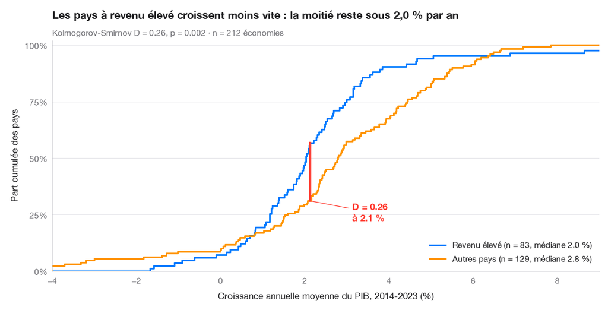

## Lire une fonction de répartition

- Pour chaque valeur de *x*, la courbe donne la **part des pays en dessous**. Pas de classes à choisir, contrairement à l’histogramme.
- On lit directement la **médiane** (là où la courbe croise 50 %) et n’importe quel quantile.
- La courbe orange est **à droite** de la bleue : à part égale, les autres pays croissent plus vite.

Retour à la manchette : si la « valeur » est la **croissance**, les économies riches — États-Unis compris (2,5 % par an) — ne sont pas en tête. C’est ce que la théorie appelle la **convergence**.

## 5 · Une distribution dans le temps : les crêtes

[distributions/ridgeline](https://warint.github.io/pystatlas/fr/distributions/ridgeline/) · *comment la croissance mondiale s’est-elle répartie, année après année ?*  
*Exemple de la galerie : fécondité des pays par décennie, de 1960 à 2010 : la transition démographique en un graphique.*

```python
annees = list(range(2007, 2024))
cr = pays[pays["annee"].isin(annees)].dropna(subset=["croissance_pib"])
cr = cr[cr["croissance_pib"].between(-15, 15)]                       # coupe les cas extrêmes
medianes = cr.groupby("annee")["croissance_pib"].median()
grid = np.linspace(-15, 15, 400)
cmap, norm = plt.get_cmap("RdBu"), plt.Normalize(-4, 8)

fig, ax = plt.subplots(figsize=(10, 5.6))
for i, a in enumerate(annees):
    base = (len(annees) - 1 - i) * 0.6                                # 2007 en haut
    kde = stats.gaussian_kde(cr.loc[cr["annee"] == a, "croissance_pib"])
    dens = kde(grid)
    courbe = base + 1.5 * dens / dens.max() * 0.6
    ax.fill_between(grid, base, courbe, color=cmap(norm(medianes[a])), alpha=0.9, lw=0, zorder=2 * i)
    ax.plot(grid, courbe, color="white", lw=1.0, zorder=2 * i + 1)
    ax.plot([medianes[a]] * 2, [base, base + 1.5 * kde(medianes[a])[0] / dens.max() * 0.6],
            color="white", lw=1.4, zorder=2 * i + 1)
ax.set_yticks([(len(annees) - 1 - i) * 0.6 for i in range(len(annees))], annees, fontsize=8)
ax.axvline(0, color="#3A3A3C", lw=0.8, zorder=100)
ax.grid(axis="x"); ax.grid(axis="y", visible=False); ax.spines["left"].set_visible(False)
ax.set_xlim(-15, 15)
ax.set_xlabel("Croissance du PIB réel (%), un pays = une observation")
recul = pays[pays["annee"].isin([2009, 2020])].groupby("annee")["croissance_pib"].apply(lambda g: (g.dropna() < 0).mean())
ax.set_title(f"Deux chocs mondiaux : {recul[2009]:.0%} des pays reculent en 2009, {recul[2020]:.0%} en 2020", pad=26)
ax.text(0, 1.02, f"Médiane mondiale : {medianes[2009]:.1f} % en 2009, {medianes[2020]:.1f} % en 2020 · "
        f"trait blanc = médiane · {len(cr)} pays-années, valeurs hors ±15 % retirées",
        transform=ax.transAxes, fontsize=10, color="#6E6E73")
plt.show()
```

## 5 · Une distribution dans le temps : les crêtes

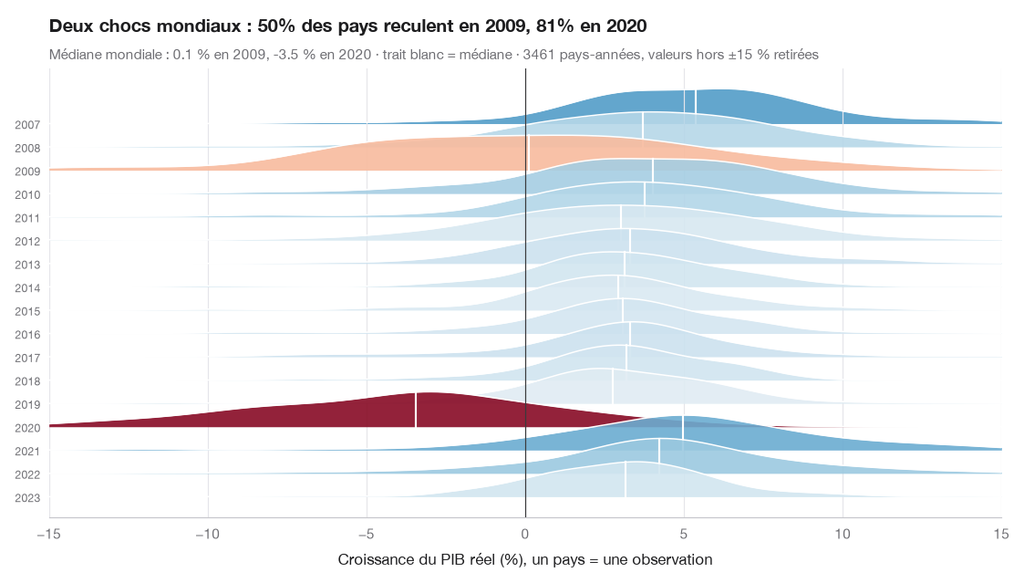

## Ce que les cinq démonstrations ont en commun

|  | Question | Famille | Graphique | Statistique en sous-titre |
| --- | --- | --- | --- | --- |
| 1 | Quelle forme ? | Distributions | Histogramme avec densité | asymétrie, aplatissement |
| 2 | Les groupes diffèrent-ils ? | Distributions | Nuage de pluie | Kruskal-Wallis, ε² |
| 3 | Vont-elles ensemble ? | Corrélation | Nuage avec statistiques | r de Pearson et son IC |
| 4 | Deux groupes, toute la distribution | Distributions | Fonctions de répartition | Kolmogorov-Smirnov D |
| 5 | La distribution change-t-elle ? | Distributions | Crêtes | médianes annuelles |

À chaque fois : **une** ligne de données changée, des **textes** réécrits, et un titre qui ose une conclusion que le sous-titre permet de vérifier.

# Ce que la galerie ne fait pas pour vous

## Les graphiques « simples » restent à votre charge

PyStatlas est une galerie de graphiques **statistiques**. Les trois formes de base de l’analyste s’écrivent en quelques lignes de matplotlib — avec le même style :

| La question | La forme | En Python |
| --- | --- | --- |
| **Comparer** des catégories | Barres horizontales triées | `ax.barh` (après `sort_values`) |
| **Suivre** une évolution | Lignes étiquetées directement | `ax.plot` + `ax.text` en bout de ligne |
| Montrer une **composition** | Barres empilées (pas de secteurs) | `df.plot.barh(stacked=True)` |

## Évolution : étiqueter le bout des lignes

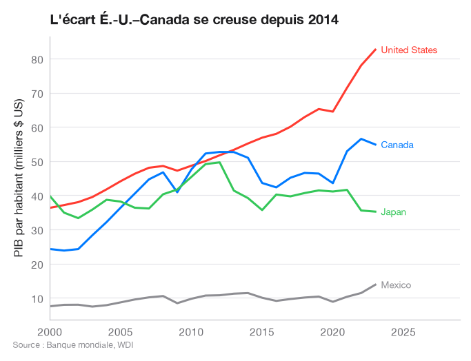

```python
couleurs = {"USA": ROUGE, "CAN": BLEU,
            "MEX": GRIS, "JPN": VERT}
fig, ax = plt.subplots(figsize=(6, 4.4))
for iso, c in couleurs.items():
    d = pays[pays["iso3"] == iso].dropna(
        subset=["pib_hab_usd"])
    ax.plot(d["annee"], d["pib_hab_usd"] / 1000, color=c)
    fin = d.iloc[-1]
    ax.text(fin["annee"] + 0.4,
            fin["pib_hab_usd"] / 1000, fin["pays"],
            color=c, va="center", fontsize=9)
ax.set_xlim(2000, 2029)
ax.set_title("L'écart É.-U.–Canada se creuse depuis 2014")
ax.set_ylabel("PIB par habitant (milliers $ US)")
fig.text(0.01, -0.02, "Source : Banque mondiale, WDI",
         fontsize=8, color=GRIS)
plt.show()
```

## Composition : barres empilées plutôt que secteurs

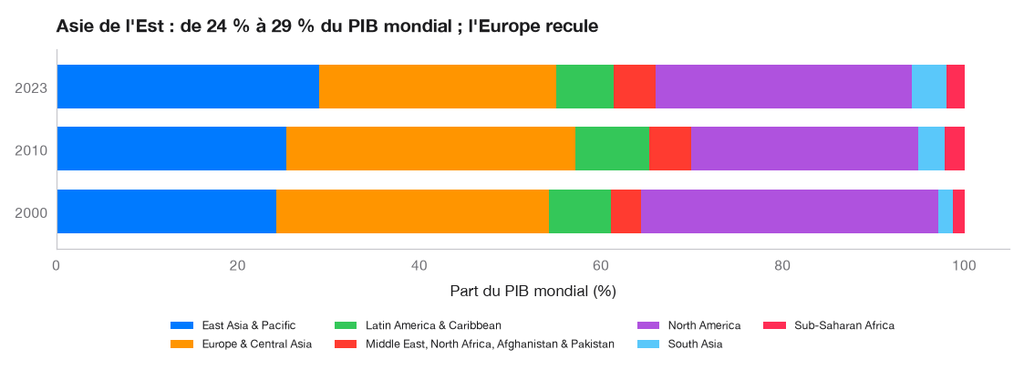

```python
comp = (pays[pays["annee"].isin([2000, 2010, 2023])]
        .groupby(["annee", "region"])["pib_milliards_usd"].sum().unstack())
comp = comp.div(comp.sum(axis=1), axis=0) * 100
ax = comp.plot.barh(stacked=True, figsize=(10, 3.4), width=0.7)
ax.set(xlabel="Part du PIB mondial (%)", ylabel="", title="Asie de l'Est : de 24 % à 29 % du PIB mondial ; l'Europe recule")
ax.legend(ncol=4, fontsize=8, loc="upper center", bbox_to_anchor=(0.5, -0.3))
ax.grid(axis="x"); ax.grid(axis="y", visible=False)
plt.show()
```

## plotly : explorer avant de conclure

La galerie produit des figures **pour un rapport**. Pour **chercher**, un nuage que l’on survole :

```python
import plotly.express as px
d = p23.dropna(subset=["pib_hab_usd", "ide_entrants_pct_pib", "population"])
d = d[d["ide_entrants_pct_pib"].between(-10, 40)]
fig = px.scatter(d, x="pib_hab_usd", y="ide_entrants_pct_pib", size="population",
                 color="region", hover_name="pays", log_x=True, size_max=45,
                 labels={"pib_hab_usd": "PIB par habitant ($, log)",
                         "ide_entrants_pct_pib": "IDE entrants (% du PIB)"},
                 height=400, width=1100)
fig.show()
```

[interactive chart not shown]

## Statique ou interactif ?

|  | matplotlib + PyStatlas | plotly |
| --- | --- | --- |
| Rapport PDF ou Word | **Oui** | Exporter une image (`fig.write_image`, paquet `kaleido`) |
| Statistique affichée sur la figure | **Oui**, c’est le principe | À ajouter à la main |
| Exploration, tableau de bord | Limité | **Oui** : survol, zoom, filtres |
| Enregistrer | `fig.savefig("x.png")` | `fig.write_html("x.html")` |

# Du mauvais graphique au bon

## L’axe tronqué

Une **barre** encode une longueur : elle doit partir de zéro. Une **ligne** peut zoomer.

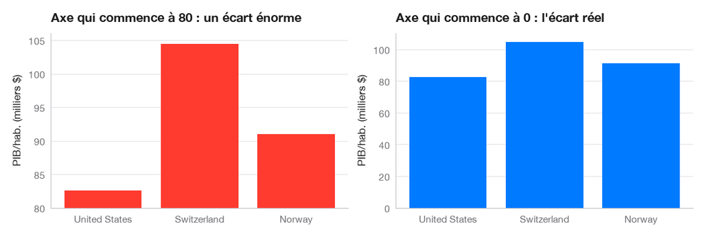

```python
top = p23.set_index("pays").loc[["United States", "Switzerland", "Norway"], "pib_hab_usd"] / 1000
fig, (a1, a2) = plt.subplots(1, 2, figsize=(10, 3.2))
a1.bar(top.index, top, color=ROUGE); a1.set_ylim(80, 106)
a1.set_title("Axe qui commence à 80 : un écart énorme")
a2.bar(top.index, top, color=BLEU); a2.set_ylim(0, 110)
a2.set_title("Axe qui commence à 0 : l'écart réel")
for a in (a1, a2):
    a.set_ylabel("PIB/hab. (milliers $)")
plt.show()
```

## Le double axe

Les deux échelles se choisissent librement : le croisement des courbes est un **artefact**. Faites deux panneaux.

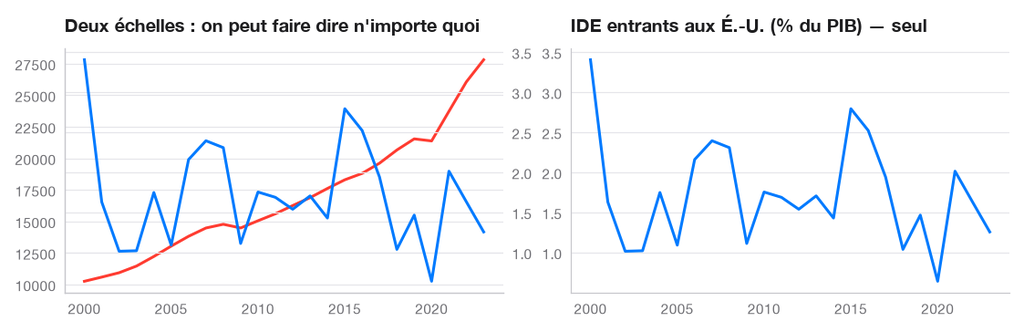

```python
us = pays[pays["iso3"] == "USA"]
fig, (a1, a2) = plt.subplots(1, 2, figsize=(10, 3.1))
a1.plot(us["annee"], us["pib_milliards_usd"], color=ROUGE)
b = a1.twinx(); b.plot(us["annee"], us["ide_entrants_pct_pib"], color=BLEU)
a1.set_title("Deux échelles : on peut faire dire n'importe quoi")
a2.plot(us["annee"], us["ide_entrants_pct_pib"], color=BLEU)
a2.set_title("IDE entrants aux É.-U. (% du PIB) — seul")
plt.show()
```

## Le camembert en 3D, et le test sans le graphique

| Défaut | Pourquoi |
| --- | --- |
| Angle **et** perspective | La part au premier plan paraît plus grosse qu’elle n’est |
| Six parts ou plus | L’œil ne compare plus les angles voisins |
| Une valeur p **sans** la distribution | On ne sait pas si l’écart est grand, ni s’il tient à trois points (Anscombe) |

**Remplacements :** des barres horizontales triées pour la composition ; un graphique PyStatlas qui montre **à la fois** chaque observation et le test.

## La grille de relecture avant de remettre une figure

1. Le **titre** énonce-t-il le message ?
2. Le **sous-titre** donne-t-il le n et la statistique qui permettent de le vérifier ?
3. Chaque axe a-t-il une **unité** ? La **source** est-elle indiquée ?
4. Les barres partent-elles de **zéro** ? Un axe coupé est-il **signalé** ?
5. Les catégories sont-elles **triées** par valeur ?
6. Une **légende** peut-elle être remplacée par un étiquetage direct ?
7. Les chiffres du titre **sortent-ils du code** ?

## Avant la pratique

- `data/pays.csv` et `data/entreprises.csv` se chargent
- `plt.style.use("05-representer-les-donnees/pystatlas.mplstyle")` fonctionne
- La galerie est ouverte dans un onglet : [warint.github.io/pystatlas/fr](https://warint.github.io/pystatlas/fr/)
- Un dossier `sorties/` existe à la racine du dépôt

**Pratique :** *À partir de la galerie, construisez le graphique qui défend — puis ceux qui réfutent — « l’Amérique crée plus de valeur que tout autre pays ».*